# R - EDA

Lydia Gathoni

29 February 2020

## Research Question

A Kenyan entrepreneur has created an online cryptography course and would want to advertise it on her blog. She currently targets audiences originating from various countries. In the past, she ran ads to advertise a related course on the same blog and collected data in the process. She would now like to employ your services as a Data Science Consultant to help her identify which individuals are most likely to click on her ads.

In order to work on the above problem, you need to do the following:

Define the question, the metric for success, the context, experimental design taken and the appropriateness of the available data to answer the given question

Find and deal with outliers, anomalies, and missing data within the dataset.

Perform univariate and bivariate analysis recording your observations.

Implement the solution by performing the respective analysis i.e. factor analysis, principal component analysis, and discriminant analysis.

Challenge your solution by providing insights on how you can make improvements.

```r
adv <- read.csv("advertising.csv")
head(adv)
```

|  | Daily.Time.Spent.on.Site | Age | Area.Income | Daily.Internet.Usage | Ad.Topic.Line | City | Male | Country | Timestamp | Clicked.on.Ad |
| --- | --- | --- | --- | --- | --- | --- | --- | --- | --- | --- |
| 1 | 68.95 | 35 | 61833.90 | 256.09 | Cloned 5thgeneration orchestration | Wrightburgh | 0 | Tunisia | 2016-03-27 00:53:11 | 0 |
| 2 | 80.23 | 31 | 68441.85 | 193.77 | Monitored national standardization | West Jodi | 1 | Nauru | 2016-04-04 01:39:02 | 0 |
| 3 | 69.47 | 26 | 59785.94 | 236.50 | Organic bottom-line service-desk | Davidton | 0 | San Marino | 2016-03-13 20:35:42 | 0 |
| 4 | 74.15 | 29 | 54806.18 | 245.89 | Triple-buffered reciprocal time-frame | West Terrifurt | 1 | Italy | 2016-01-10 02:31:19 | 0 |
| 5 | 68.37 | 35 | 73889.99 | 225.58 | Robust logistical utilization | South Manuel | 0 | Iceland | 2016-06-03 03:36:18 | 0 |
| 6 | 59.99 | 23 | 59761.56 | 226.74 | Sharable client-driven software | Jamieberg | 1 | Norway | 2016-05-19 14:30:17 | 0 |

### Explore the dataset

Summary, information, dimension

```r
# summary of the dataset
summary(adv)
```

```
##  Daily.Time.Spent.on.Site      Age         Area.Income    Daily.Internet.Usage
##  Min.   :32.60            Min.   :19.00   Min.   :13996   Min.   :104.8
##  1st Qu.:51.36            1st Qu.:29.00   1st Qu.:47032   1st Qu.:138.8
##  Median :68.22            Median :35.00   Median :57012   Median :183.1
##  Mean   :65.00            Mean   :36.01   Mean   :55000   Mean   :180.0
##  3rd Qu.:78.55            3rd Qu.:42.00   3rd Qu.:65471   3rd Qu.:218.8
##  Max.   :91.43            Max.   :61.00   Max.   :79485   Max.   :270.0
##
##                                  Ad.Topic.Line              City
##  Adaptive 24hour Graphic Interface      :  1   Lisamouth      :  3
##  Adaptive asynchronous attitude         :  1   Williamsport   :  3
##  Adaptive context-sensitive application :  1   Benjaminchester:  2
##  Adaptive contextually-based methodology:  1   East John      :  2
##  Adaptive demand-driven knowledgebase   :  1   East Timothy   :  2
##  Adaptive uniform capability            :  1   Johnstad       :  2
##  (Other)                                :994   (Other)        :986
##       Male                 Country                  Timestamp   Clicked.on.Ad
##  Min.   :0.000   Czech Republic:  9   2016-01-01 02:52:10:  1   Min.   :0.0
##  1st Qu.:0.000   France        :  9   2016-01-01 03:35:35:  1   1st Qu.:0.0
##  Median :0.000   Afghanistan   :  8   2016-01-01 05:31:22:  1   Median :0.5
##  Mean   :0.481   Australia     :  8   2016-01-01 08:27:06:  1   Mean   :0.5
##  3rd Qu.:1.000   Cyprus        :  8   2016-01-01 15:14:24:  1   3rd Qu.:1.0
##  Max.   :1.000   Greece        :  8   2016-01-01 20:17:49:  1   Max.   :1.0
##                  (Other)       :950   (Other)            :994
```

```r
# information about the dataset
str(adv)
```

```
## 'data.frame':    1000 obs. of  10 variables:
##  $ Daily.Time.Spent.on.Site: num  69 80.2 69.5 74.2 68.4 ...
##  $ Age                     : int  35 31 26 29 35 23 33 48 30 20 ...
##  $ Area.Income             : num  61834 68442 59786 54806 73890 ...
##  $ Daily.Internet.Usage    : num  256 194 236 246 226 ...
##  $ Ad.Topic.Line           : Factor w/ 1000 levels "Adaptive 24hour Graphic Interface",..: 92 465 567 904 767 806 223 724 108 455 ...
##  $ City                    : Factor w/ 969 levels "Adamsbury","Adamside",..: 962 904 112 940 806 283 47 672 885 713 ...
##  $ Male                    : int  0 1 0 1 0 1 0 1 1 1 ...
##  $ Country                 : Factor w/ 237 levels "Afghanistan",..: 216 148 185 104 97 159 146 13 83 79 ...
##  $ Timestamp               : Factor w/ 1000 levels "2016-01-01 02:52:10",..: 440 475 368 57 768 690 131 334 549 942 ...
##  $ Clicked.on.Ad           : int  0 0 0 0 0 0 0 1 0 0 ...
```

```r
# dimension of the dataset
dim(adv)
```

```
## [1] 1000   10
```

The dataset has 1000 rows and 10 columns

### Data Cleaning

#### Missing Values

```r
# Total missing values in each column
# by using the function colSums()

colSums(is.na(adv))
```

```
## Daily.Time.Spent.on.Site                      Age              Area.Income
##                        0                        0                        0
##     Daily.Internet.Usage            Ad.Topic.Line                     City
##                        0                        0                        0
##                     Male                  Country                Timestamp
##                        0                        0                        0
##            Clicked.on.Ad
##                        0
```

Our dataset has no missing values

#### Duplicated rows

```r
# duplicated rows in the dataset df
# and assign to a variable duplicated_rows

duplicated_rows <- adv[duplicated(adv),]

# Lets print out the variable duplicated_rows and see these duplicated rows

duplicated_rows
```

| Daily.Time.Spent.on.Site | Age | Area.Income | Daily.Internet.Usage | Ad.Topic.Line | City | Male | Country | Timestamp | Clicked.on.Ad |
| --- | --- | --- | --- | --- | --- | --- | --- | --- | --- |

We have no duplicated rows in the dataset

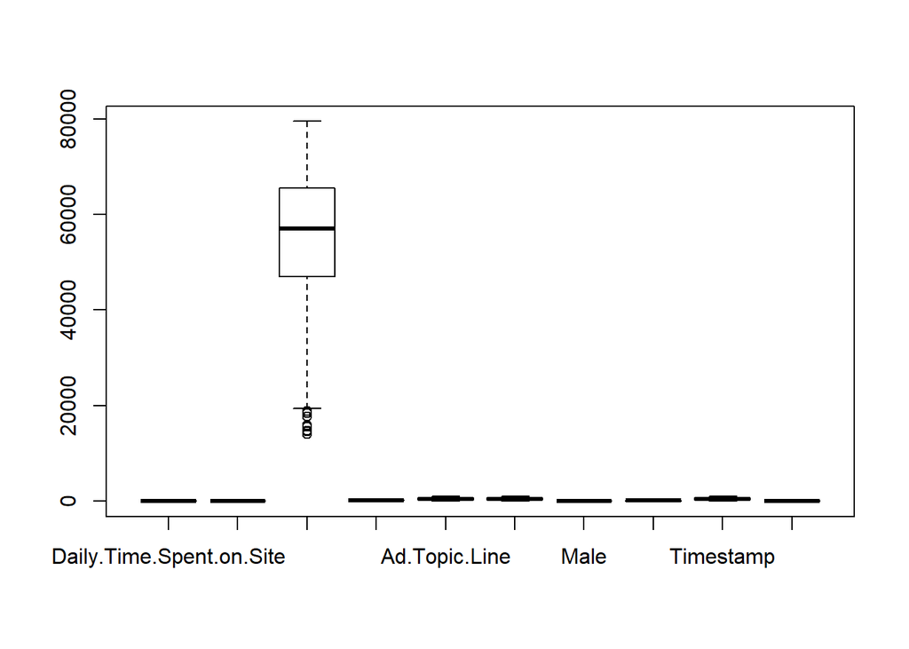

```r
# plot a boxplot to help us visualise any existing outliers

boxplot(adv
        )
```

We identify outliers in the Area.Income column We can narrow down to list out the outliers in that column

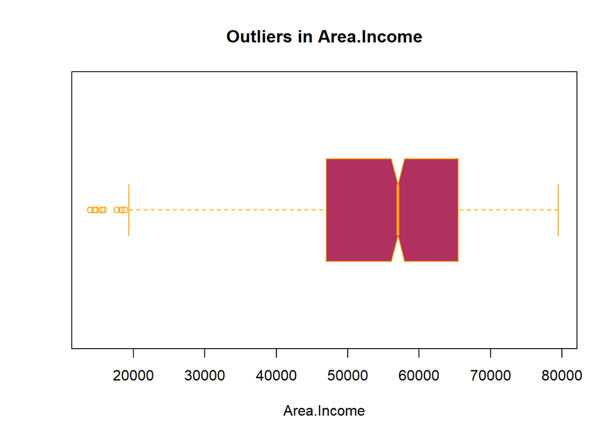

```r
boxplot(adv$Area.Income,
main = "Outliers in Area.Income",
xlab = "Area.Income",
col = "maroon",
border = "orange",
horizontal = TRUE,
notch = TRUE
)
```

We identify outliers in the column

### Exploratory Data Analysis

#### Univariate Analysis

```r
table(adv$Age)
```

```
##
## 19 20 21 22 23 24 25 26 27 28 29 30 31 32 33 34 35 36 37 38 39 40 41 42 43 44
##  6  6  6 13 19 21 27 37 33 48 48 39 60 38 43 39 39 50 36 37 30 36 32 26 23 21
## 45 46 47 48 49 50 51 52 53 54 55 56 57 58 59 60 61
## 30 18 13 16 18 20 12 15 10  9  7  2  6  4  2  4  1
```

Most of the people in the dataset are 31 years with 60 people

#### Mean daily time spent on site

```r
# mean of the daily time spent on site
mean(adv$Daily.Time.Spent.on.Site)
```

```
## [1] 65.0002
```

65 minutes is the average time spent on site

#### Mean daily internet usage

```r
mean(adv$Daily.Internet.Usage)
```

```
## [1] 180.0001
```

180 minutes is the average daily internet usage

##### Histograms

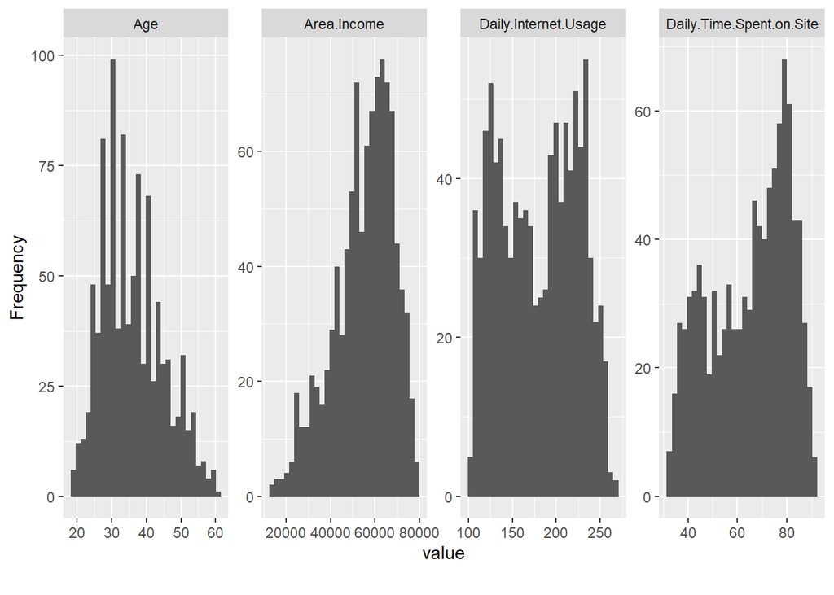

```r
# Histograms
library(DataExplorer)
plot_histogram(adv)
```

##### Daily Time spent on site

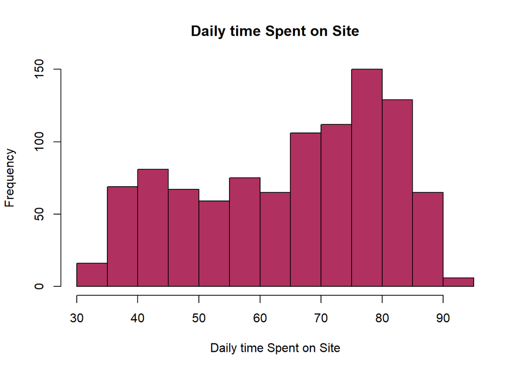

```r
# Daily time spent on site distribution
#
x = hist(adv$Daily.Time.Spent.on.Site,
         main = "Daily time Spent on Site",
         xlab = "Daily time Spent on Site",
         col = "maroon"
)
```

```r
summary(adv$Daily.Time.Spent.on.Site)
```

```
##    Min. 1st Qu.  Median    Mean 3rd Qu.    Max.
##   32.60   51.36   68.22   65.00   78.55   91.43
```

##### Daily Internet Usage

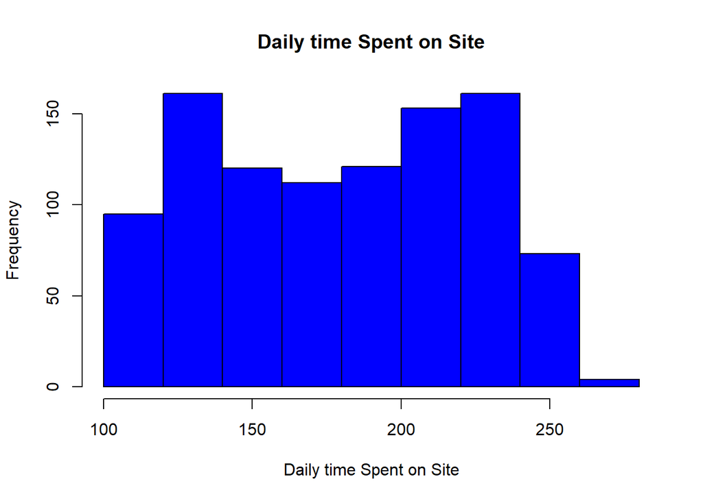

```r
# Daily Internet Usage
#
y = hist(adv$Daily.Internet.Usage,
         main = "Daily time Spent on Site",
         xlab = "Daily time Spent on Site",
         col = "blue"
)
```

```r
summary(adv$Daily.Internet.Usage)
```

```
##    Min. 1st Qu.  Median    Mean 3rd Qu.    Max.
##   104.8   138.8   183.1   180.0   218.8   270.0
```

The average daily internet usage is 180 minutes

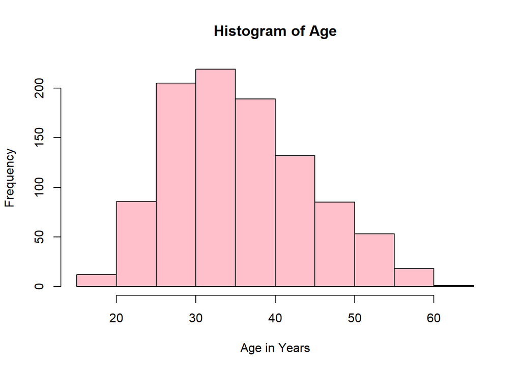

```r
hist(adv$Age,
     main = "Histogram of Age",
     xlab = "Age in Years",
     col = "pink")
```

Most people are between age 30 and 35 with the least being above 60

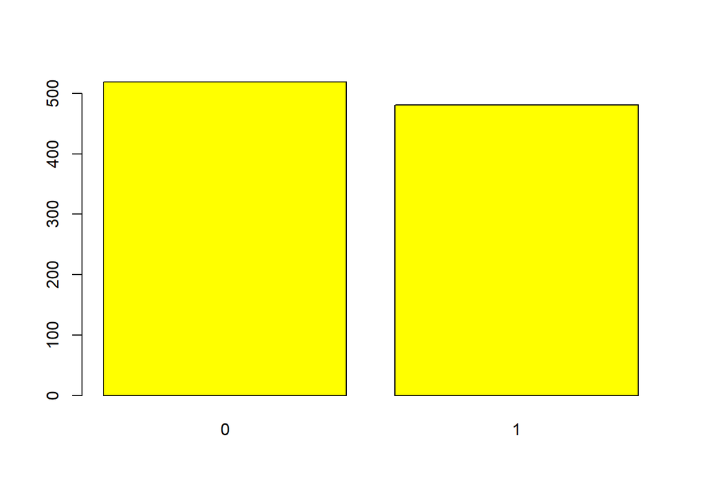

```r
 # fetch the frequency of gender from the dataset
gender <- adv$Male
gender_freq <- table(gender)
barplot(gender_freq,
        col = "yellow")
```

The females represented by 0 are more than the males

##### Distribution of Area income

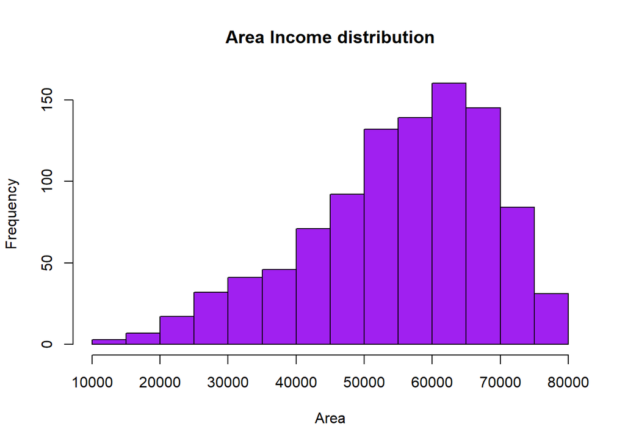

```r
z = hist(adv$Area.Income,
         main = "Area Income distribution",
         xlab = "Area",
         col = "purple"
)
```

##### Pie Chart

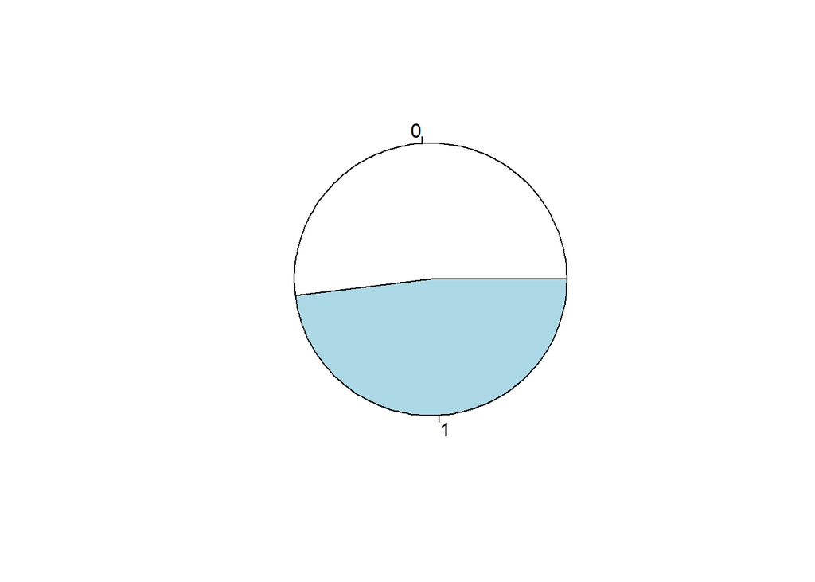

```r
library(DataExplorer)
pie(table(adv$Male))
```

0 value which represents females is more than 1 which represents males

##### Density plot

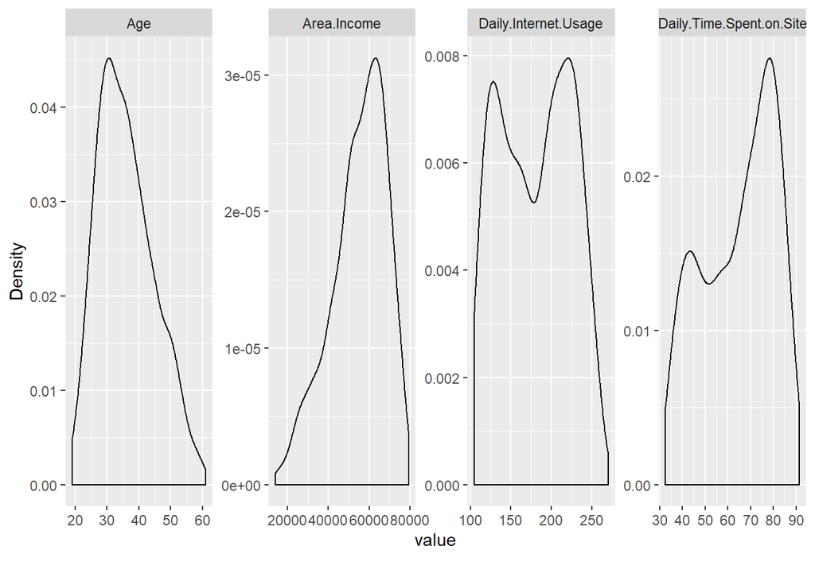

```r
library(DataExplorer)
plot_density(adv)
```

#### Bivariate Analysis

```r
# checking for covariance
# covariance is a number that reflects the degree to which two variable vary together

timespent <- adv$Daily.Time.Spent.on.Site
internetusage<- adv$Daily.Internet.Usage

# Using the cov() function to determine the covariance

cov(timespent, internetusage)
```

```
## [1] 360.9919
```

Correlation

```r
# checking for correlation
# correlation is a normalized measurement of how the two are linearly related

timespent <- adv$Daily.Time.Spent.on.Site
internetusage<- adv$Daily.Internet.Usage

# Using the cor() function to determine the covariance

cor(timespent, internetusage)
```

```
## [1] 0.5186585
```

Shows a relation between the two

##### Scatterplot

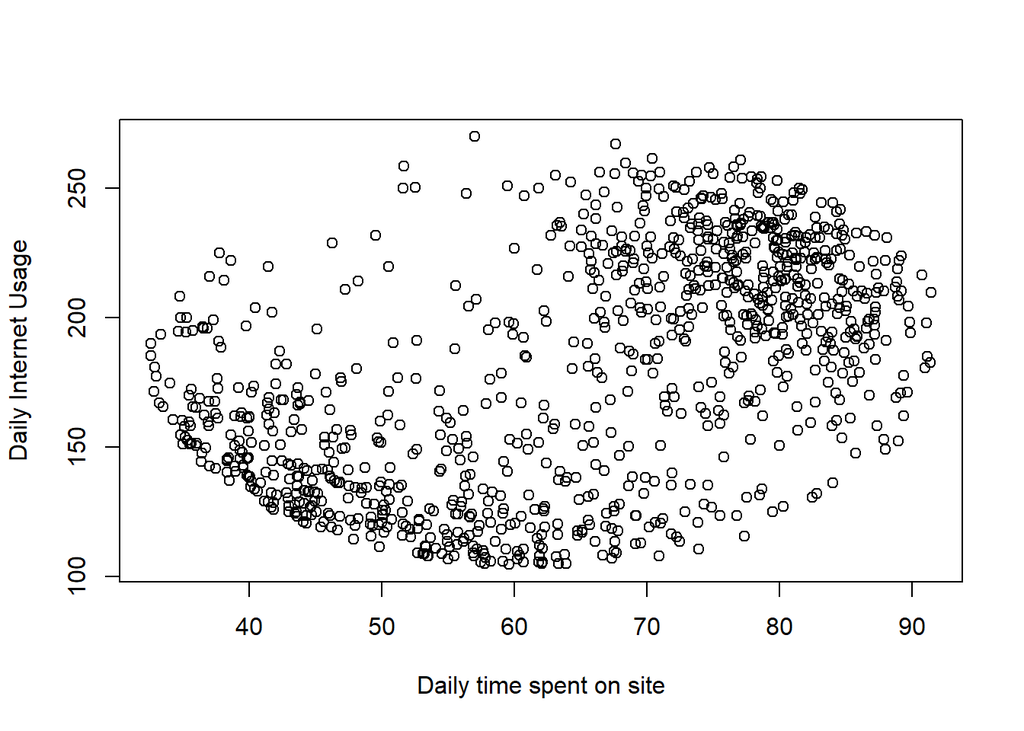

```r
# Scatterplot

timespent <- adv$Daily.Time.Spent.on.Site
internetusage<- adv$Daily.Internet.Usage

plot(timespent, internetusage, xlab="Daily time spent on site", ylab="Daily Internet Usage")
```

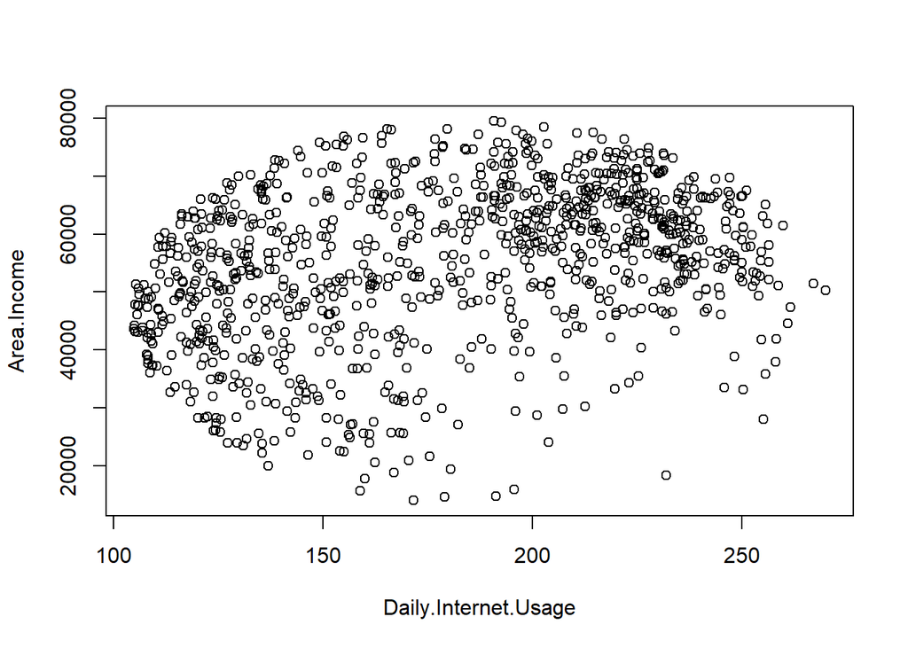

```r
plot(Area.Income ~ Daily.Internet.Usage, data = adv)
```

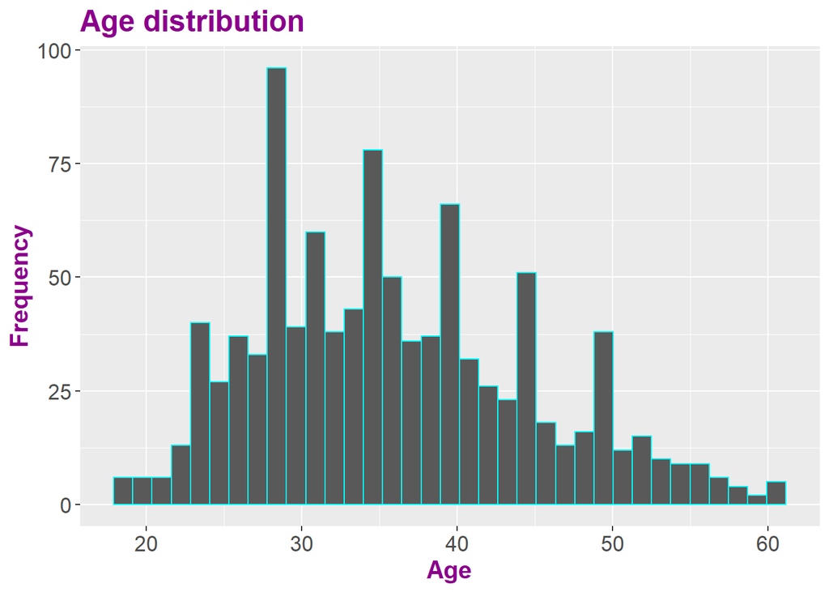

```r
# Plotting a a pair of histograms
library(ggplot2)
options(repr.plot.width = 13, repr.plot.height = 7)
ggplot(data = adv, aes(x = Age, fill = Clicked.on.Ad))+
    geom_histogram(bins = 35, color = 'cyan') +
    labs(title = 'Age distribution', x = 'Age', y = 'Frequency', fill = 'Clicked on ad') +
        scale_color_brewer(palette = 'Set1') +
        theme(plot.title = element_text(size = 18, face = 'bold', color = 'darkmagenta'),
             axis.title.x = element_text(size = 15, face = 'bold', color = 'darkmagenta'),
             axis.title.y = element_text(size = 15, face = 'bold', color = 'darkmagenta'),
             axis.text.x = element_text(size = 13, angle = 0),
             axis.text.y = element_text(size = 13),
             legend.title = element_text(size = 13, color = 'darkmagenta'),
             legend.text = element_text(size = 12))
```

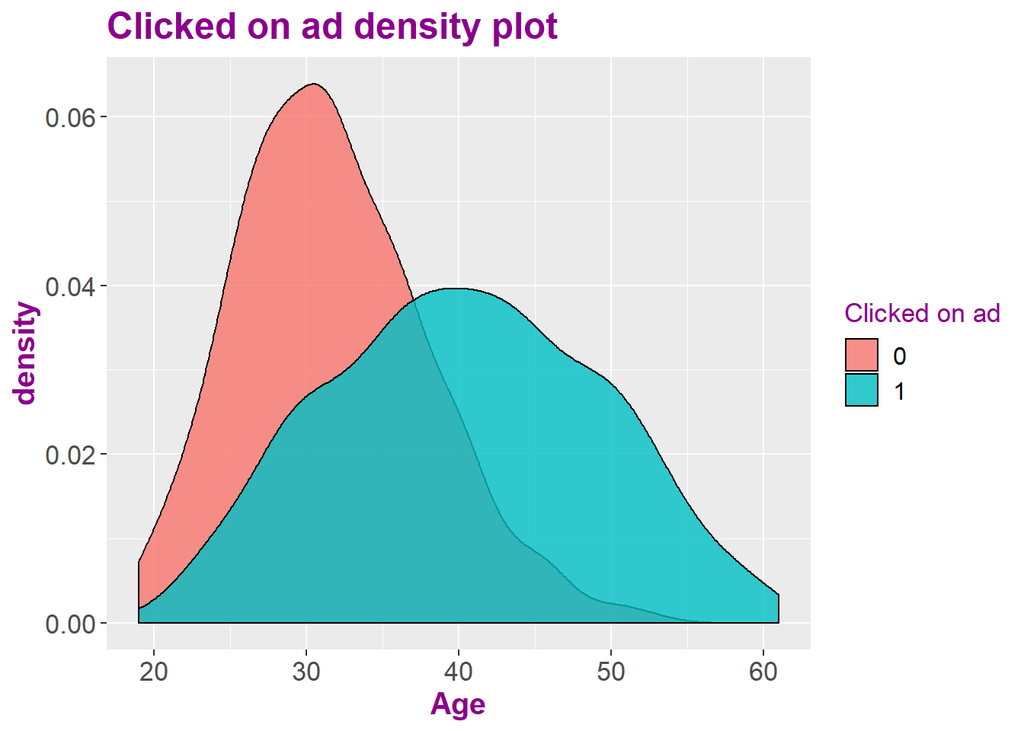

```r
# Plotting density plot
library(ggplot2)
options(repr.plot.width = 13, repr.plot.height = 7)
p1 = ggplot(data = adv, aes(Age)) +
        geom_density(aes(fill=factor(Clicked.on.Ad)), alpha = 0.8) +
        labs(title = 'Clicked on ad density plot', x = 'Age', fill = 'Clicked on ad') +
        scale_color_brewer(palette = 'cool') +
        theme(plot.title = element_text(size = 18, face = 'bold', color = 'darkmagenta'),
             axis.title.x = element_text(size = 15, face = 'bold', color = 'darkmagenta'),
             axis.title.y = element_text(size = 15, face = 'bold', color = 'darkmagenta'),
             axis.text.x = element_text(size = 13, angle = 0),
             axis.text.y = element_text(size = 13),
             legend.title = element_text(size = 13, color = 'darkmagenta'),
             legend.text = element_text(size = 12))
plot(p1)
```

```r
coad_frequency = table(adv$Clicked.on.Ad)
coad_frequency
```

```
##
##   0   1
## 500 500
```

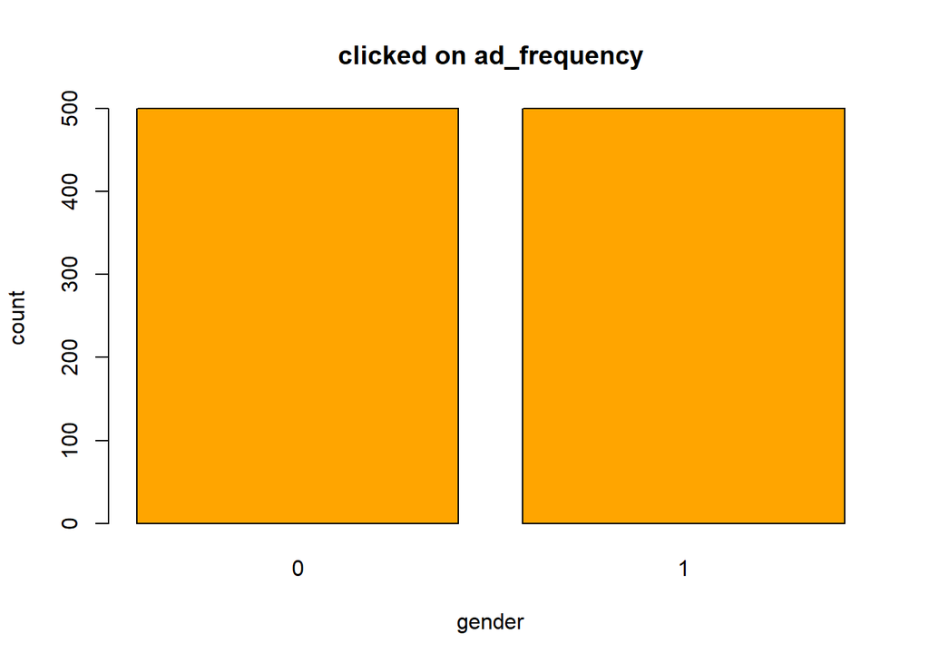

```r
# Barplot for clicked on ad variable.
#
bar_coad = barplot(coad_frequency,
                   main = 'clicked on ad_frequency',
                   xlab = 'gender',
                   ylab = 'count',
                   col = 'orange')
```

The values 0 and 1 in the variable are even. This is a perrfectly balanced dataset.

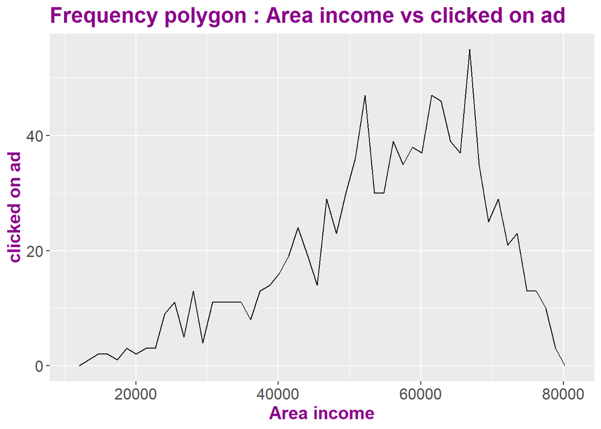

```r
# Frequency polygon
library(ggplot2)
options(repr.plot.width = 13, repr.plot.height = 7)
ggplot(data = adv, aes(x = Area.Income, col = Clicked.on.Ad))+
    geom_freqpoly(bins = 50)+
    labs(title = 'Frequency polygon : Area income vs clicked on ad', x = 'Area income', y = 'clicked on ad', fill = 'Clicked on ad') +
        scale_color_brewer(palette = 'Set1') +
        theme(plot.title = element_text(size = 18, face = 'bold', color = 'darkmagenta'),
             axis.title.x = element_text(size = 15, face = 'bold', color = 'darkmagenta'),
             axis.title.y = element_text(size = 15, face = 'bold', color = 'darkmagenta'),
             axis.text.x = element_text(size = 13),
             axis.text.y = element_text(size = 13),
             legend.title = element_text(size = 13, color = 'darkmagenta'),
             legend.text = element_text(size = 12))
```

#### Multivariate Analysis

##### Correlation Plot

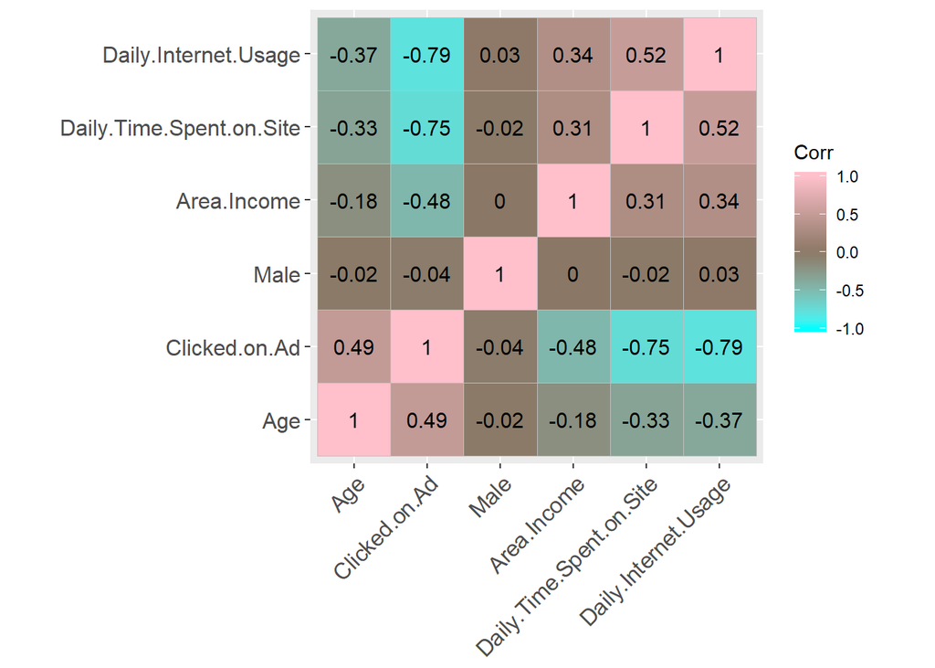

```r
library(ggcorrplot)
library(dplyr)
corr = round(cor(select_if(adv, is.numeric)), 4)
ggcorrplot(corr, hc.order = T, ggtheme = ggplot2::theme_grey,
   colors = c("cyan", "peachpuff4", "pink"), lab = T)
```

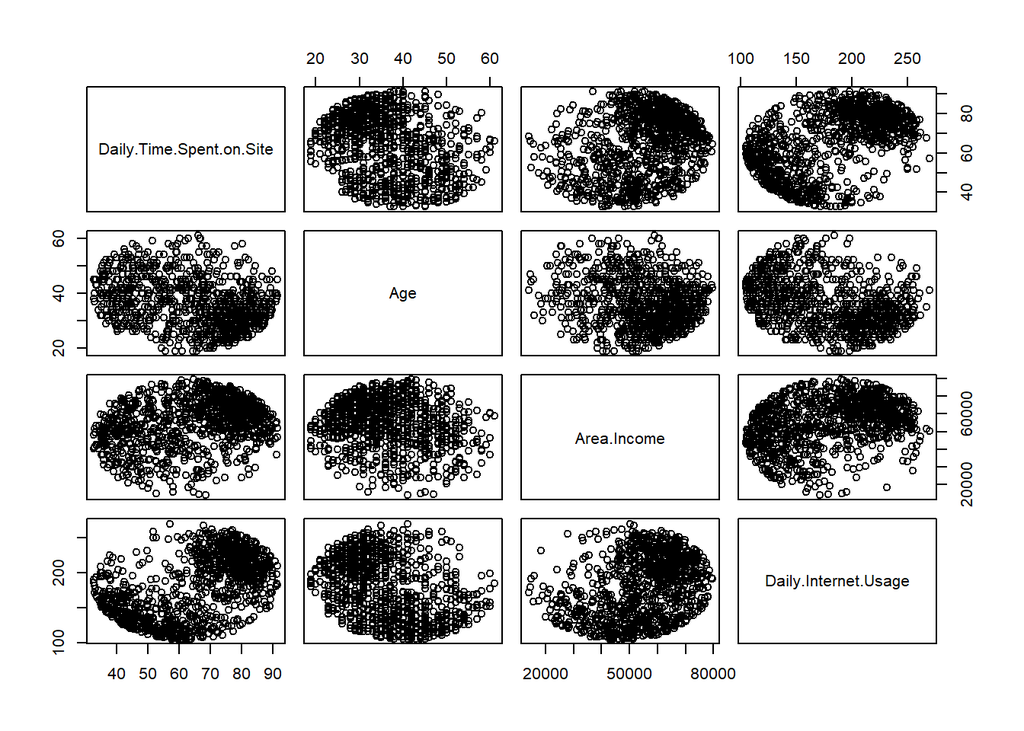

```r
# Pairplot
pairs(adv[,c(1,2,3,4)])
```